## Data Processing

Data was taken from the US National Oceanic and Atmospheric Administration’s (NOAA) database.

```r
setwd(paste('/home/tom/scripts/gnuR/coursera/datasciencecoursera/',
      'reproducible_research/peer_assgn_2', sep=""))
if(!file.exists('data')){
    dir.create('data')
}
file_url = paste('https://d396qusza40orc.cloudfront.net',
                 '/repdata%2Fdata%2FStormData.csv.bz2', sep="")
download.file(file_url, destfile = './data/NOAA_data.bz2', method="curl")
#Note: a .bz2 unzip utility could not be found. The file must be manually
#unzipped into the `working_directory/data` folder
NOAA <- read.csv('./data/NOAA_data', header=TRUE)
```

The event types were adjusted and homogenized using text matching. Those that didn’t fit into a category were classified as “Other,” and were later evaluated to check the size and importance of that category. It turned out that, of 18 events classified and one “Other” category, the 10th largest event by economic impact is approximately the same size as the last 9 categories aggregated. This implies that a sufficient amount of categories were described in order to catch the most important types of weather event.

The property and crop damage exponents were multiplied with the given values to get the real monetary values. A few cases (around 400) had unknown exponent values, hence these were discarded.

```r
evs <- tolower(NOAA$EVTYPE)
events <- rep("Other", length(evs))
events[c(grep("flood", evs), grep("flooding", evs), grep("rising water", evs),
      grep("floood", evs))] <- "Flood"
events[c(grep("tornado", evs), grep("torndao", evs))] <- "Tornado"
events[c(grep("hail", evs), grep("freezing", evs), grep("ice", evs),
      grep("glaze", evs), grep("icy", evs))] <-
    "Hail/Freezing Rain/Ice"
events[c(grep("winter", evs), grep("snow", evs), grep("sleet", evs),
      grep("blizzard", evs), grep("wintry", evs), grep("mix", evs))] <-
    "Winter/Snow/Blizzard"
events[c(grep("tide", evs), grep("coastal", evs), grep("surf", evs),
      grep("sea", evs), grep("wave", evs), grep("surge", evs),
      grep("swell", evs))] <- "Tide/Wave Event"
events[c(grep("summary", evs), grep("remnant", evs))] <- NA
events[c(grep("hurricane", evs), grep("tsunami", evs), grep("tropical", evs),
      grep("typhoon", evs))] <- "Hurricane/Tsunami/Tropical Storm"
events[c(grep("wind", evs), grep("wnd", evs))] <- "Wind"
events[c(grep("dry", evs), grep("drought", evs))] <- "Dry/Drought"
events[c(grep("cold", evs), grep("frost", evs), grep("cool", evs),
      grep("freeze", evs), grep("low temperature", evs),
      grep("record low", evs))] <- "Cold"
events[grep("volcan", evs)] <- "Volcanic Ash"
events[grep("fire", evs)] <- "Wildfire"
events[c(grep("thunderstorm", evs), grep("lightning", evs),
      grep("lighting", evs), grep("ligntning", evs))] <- "Thunderstorms"
events[c(grep("mud", evs), grep("rock", evs), grep("landslide", evs),
      grep("landslump", evs))] <- "Mudslide/Rockslide/Landslide"
events[c(grep("avalance", evs), grep("avalanche", evs))] <- "Avalanche"
events[c(grep("warm", evs), grep("heat", evs), grep("hot", evs),
      grep("record high", evs), grep("hyperthermia", evs),
      grep("high temperature", evs))] <- "Heat"
events[c(grep("rain", evs), grep("wet", evs), grep("precipitation", evs),
      grep("precipatation", evs), grep("showers", evs))] <- "Rain"
events[c(grep("fog", evs), grep("vog", evs))] <- "Fog"
events[c(grep("spout", evs))] <- "Waterspouts"

prop.dmg <- NOAA$PROPDMG
prop.dmg[prop.dmg==""] <- 0
prop.factor <- rep(NA, length(prop.dmg))
prop.factor[NOAA$PROPDMGEXP==""] <- 1
prop.factor[((NOAA$PROPDMGEXP=="k") | (NOAA$PROPDMGEXP=="K"))] <- 1e3
prop.factor[((NOAA$PROPDMGEXP=="m") | (NOAA$PROPDMGEXP=="M"))] <- 1e6
prop.factor[((NOAA$PROPDMGEXP=="b") | (NOAA$PROPDMGEXP=="B"))] <- 1e9
#There is a serious error in this reference to the Napa Valley floods in
#January 2006
prop.factor[(NOAA$REFNUM==605943)] <- 1e6
prop.dmg <- prop.dmg*prop.factor/1e6

crop.dmg <- NOAA$CROPDMG
crop.dmg[prop.dmg==""] <- 0
crop.factor <- rep(NA, length(crop.dmg))
crop.factor[NOAA$CROPDMGEXP==""] <- 1
crop.factor[((NOAA$CROPDMGEXP=="k") | (NOAA$CROPDMGEXP=="K"))] <- 1e3
crop.factor[((NOAA$CROPDMGEXP=="m") | (NOAA$CROPDMGEXP=="M"))] <- 1e6
crop.factor[((NOAA$CROPDMGEXP=="b") | (NOAA$CROPDMGEXP=="B"))] <- 1e9
crop.dmg <- crop.dmg*crop.factor/1e6

date <- strptime(NOAA$BGN_DATE, "%m/%d/%Y %H:%M:%S")

NOAA.clean <- data.frame("Date"=date, "State"=NOAA$STATE, "Event"=events,
                         "Fatalities"=NOAA$FATALITIES,
                         "Injuries"=NOAA$INJURIES, "Property.Damage"=prop.dmg,
                         "Crop.Damage"=crop.dmg,
                         "Year"=as.numeric(format(date, "%Y")))
NOAA.clean <- NOAA.clean[complete.cases(NOAA.clean), ]
remove(NOAA)
```

## Results: Human Impact

Total casualties (deaths plus injuries) were analyzed across the different weather event types.

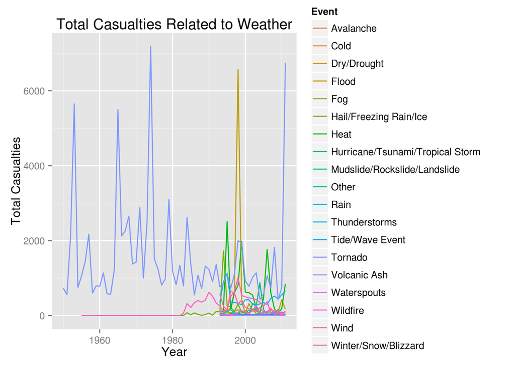

```r
total.casualties <- aggregate((NOAA.clean$Fatalities +
                                 NOAA.clean$Injuries),
                           by=list(NOAA.clean$Event, NOAA.clean$Year),
                           FUN=sum)
names(total.casualties) <- c("Event", "Year", "Total.Casualties")

library(ggplot2)
qplot(Year, Total.Casualties, data=total.casualties, color=Event, geom="line",
      ylab="Total Casualties", main="Total Casualties Related to Weather")
```

If the total casualties are summed across the recorded years, the effects of other weather events are easier to perceive.

```r
casualties.totals <- aggregate((NOAA.clean$Fatalities + NOAA.clean$Injuries),
                         by=list(NOAA.clean$Event), FUN=sum)
names(casualties.totals) <- c("Event", "Total.Casualties")
casualties.totals<- casualties.totals[order(casualties.totals$Total.Casualties,
                                             decreasing=TRUE), ]
print(casualties.totals)
```

```
##                               Event Total.Casualties
## 14                          Tornado            96969
## 7                              Heat            12422
## 4                             Flood            10114
## 18                             Wind            10011
## 12                    Thunderstorms             8736
## 19             Winter/Snow/Blizzard             4424
## 6            Hail/Freezing Rain/Ice             3911
## 8  Hurricane/Tsunami/Tropical Storm             2077
## 10                            Other             1750
## 17                         Wildfire             1698
## 5                               Fog             1158
## 2                              Cold              781
## 13                  Tide/Wave Event              528
## 11                             Rain              419
## 1                         Avalanche              396
## 9      Mudslide/Rockslide/Landslide               99
## 16                      Waterspouts               78
## 3                       Dry/Drought               36
## 15                     Volcanic Ash                0
```

## Results: Economic Impact

Crop damage and property damage can be summed together for a total economic impact estimate.

It’s important to note, for instance, that a large amount of damage from Hurrican Katrina in 2005, namely $31.3 billion, is classified as “Storm Surge”, which I reclassified as “Tide/Wave Event”

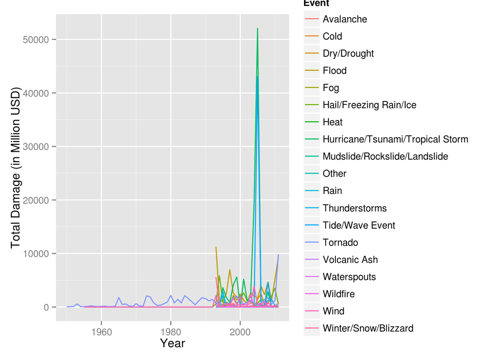

```r
total.dmg.year <- aggregate((NOAA.clean$Property.Damage +
                                 NOAA.clean$Crop.Damage),
                           by=list(NOAA.clean$Event, NOAA.clean$Year),
                           FUN=sum)
names(total.dmg.year) <- c("Event", "Year", "Total.Damage")

qplot(Year, Total.Damage, data=total.dmg.year, color=Event, geom="line",
      ylab="Total Damage (in Million USD)")
```

If the total damage is summed across the recorded years, the effects of other weather events are easier to perceive.

```r
hist.totals <- aggregate((NOAA.clean$Property.Damage + NOAA.clean$Crop.Damage),
                         by=list(NOAA.clean$Event), FUN=sum)
names(hist.totals) <- c("Event", "Total.Damage")
hist.totals <- hist.totals[order(hist.totals$Total.Damage, decreasing=TRUE), ]
print(hist.totals)
```

```
##                               Event Total.Damage
## 8  Hurricane/Tsunami/Tropical Storm    99317.633
## 4                             Flood    64444.115
## 14                          Tornado    57306.715
## 13                  Tide/Wave Event    48506.003
## 6            Hail/Freezing Rain/Ice    27988.244
## 3                       Dry/Drought    15025.420
## 18                             Wind    13794.225
## 17                         Wildfire     8899.910
## 19             Winter/Snow/Blizzard     8681.984
## 12                    Thunderstorms     8031.326
## 11                             Rain     4403.871
## 2                              Cold     3613.606
## 7                              Heat      924.805
## 9      Mudslide/Rockslide/Landslide      347.469
## 10                            Other       80.676
## 16                      Waterspouts       60.738
## 5                               Fog       25.011
## 1                         Avalanche        8.722
## 15                     Volcanic Ash        0.500
```

The top 10 largest contributors are shown below.

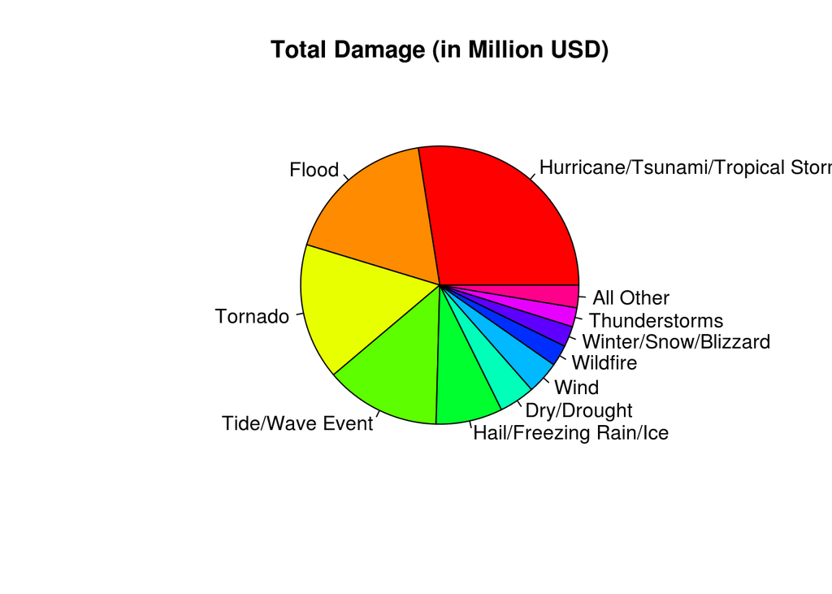

```r
other.events <- sum(hist.totals$Total.Damage[11:dim(hist.totals)[1]])
top.damage <- data.frame(c(hist.totals$Total.Damage[1:10], other.events),
                           row.names=c(as.character(hist.totals$Event[1:10]),
                                       "All Other"))
names(top.damage) <- "Damage"
pie(top.damage$Damage, labels=row.names(top.damage),
    main="Total Damage (in Million USD)", col=rainbow(11))
```

## Conclusions

Clearly, tornados cause the largest human impact. The results in terms of economic impact are less clear, as one single event, Hurricane Katrina, caused a massive amount of damage. However, it is not trivial to remove this event from the existing dataset, as the entries are mixed into different categories such as “Storm Surge,” “Hurricane,” and possibly others.